# OctaveTutorial_ger

## Einführung zu Octave

### Ausführung von Code

Wir arbeiten in diesem Tutorial mit dem Octave-Kernel für Jupyter Notebook,  
Octave kann man aber auch über das Terminal, oder das OctaveGUI ausführen.

### Dokumentation

Zu jeder vordefinierten Funktion lässt sich die (englische) Dokumentation mit "help Funktionsname" aufrufen

#### Beispiel:

```matlab
help log
```

```
'log' is a built-in function from the file libinterp/corefcn/mappers.cc

 -- Mapping Function: log (X)
     Compute the natural logarithm, 'ln (X)', for each element of X.

     To compute the matrix logarithm, see *note Linear Algebra::.

     See also: exp, log1p, log2, log10, logspace.

Additional help for built-in functions and operators is
available in the online version of the manual.  Use the command
'doc <topic>' to search the manual index.

Help and information about Octave is also available on the WWW
at http://www.octave.org and via the help@octave.org
mailing list.
```

### Good to know

- 1-basiertes Indexing
- Dynamic typing
- Matlab-Kompatibilität (weitestgehend zumindest)
- Funktionsargumente können Listen variabler Länge sein
- Returnwerte können Listen variabler Länge sein

### Intro

**Reelle und komplexe Skalare**

```matlab
realScalar = 5
```

```
realScalar =  5
```

```matlab
complexScalar = 5 + 2i;
```

Eingabe des Namens einer Variablen gibt diese aus, anhängen von einem ";" an ein statement unterdrückt den Output (nützlich bei 1000x1000 Matrizen etc):

```matlab
complexScalar
```

```
complexScalar =  5 + 2i
```

```matlab
complexScalar+=2;
```

**Matrizen**

```matlab
ZeilenVektor = [1 2 3 4 5] %Mit Beistrichen kann man auch trennen
```

```
ZeilenVektor =

   1   2   3   4   5
```

```matlab
ZeilenVektor = 1:5
ZeilenVektor = 1:2:5 %range mit inkrement
```

```
ZeilenVektor =

   1   2   3   4   5

ZeilenVektor =

   1   3   5
```

```matlab
SpaltenVektor = [1; 2; 3; 4; 5]
```

```
SpaltenVektor =

   1
   2
   3
   4
   5
```

```matlab
SpaltenVektor = (1:5)' %Der Operator ' transponiert
```

```
SpaltenVektor =

   1
   2
   3
   4
   5
```

```matlab
# Operatorpräzedenz ist wichtig:
SpaltenVektor = 1:5'
```

```
SpaltenVektor =

   1   2   3   4   5
```

```matlab
Matrix = [1 2 3; 4 5 6; 7 8 9] %Zeilen werden durch ; getrennt
```

```
Matrix =

   1   2   3
   4   5   6
   7   8   9
```

Matrizen können auch komplexwertige Einträge haben.

**Index Expressions**

```matlab
a = [1:2; 3:4]
```

```
a =

   1   2
   3   4
```

```matlab
a(:)       # Liste alle Elemente, Spalten untereinander
a(:)'      # Dasselbe als Zeilenvektor
```

```
ans =

   1
   3
   2
   4

ans =

   1   3   2   4
```

```matlab
a(2)       # Skalar
a(1:2)     # Zeilenvektor
a([1; 3])  # Spaltenvektor
```

```
ans =  3
ans =

   1   3

ans =

   1
   2
```

```matlab
% a(i,j)      # Zeile i, Spalte j
a(1, [1, 2])  # Zeile 1, Spalten 1 und 2
a(1, 1:2)     # Zeile 1, Spalten 1-2
a(1, :)       # Zeile 1, alle Spalten
```

```
ans =

   1   2

ans =

   1   2

ans =

   1   2
```

```matlab
a = [1, 2, 3, 4];

a(1:end/2)        # Erste Hälfte von a => [1, 2]
a(end + 1) = 5;   # Element hinten anhängen
a(end) = [];      # Letztes Element löschen
a(1:2:end)        # Elemente mit ungeraden Indizes => [1, 3]
a(2:2:end)        # Elemente mit geraden Indizes => [2, 4]
a(end:-1:1)       # Umkehrung von a => [4, 3, 2 , 1]
```

```
ans =

   1   2

ans =

   1   3

ans =

   2   4

ans =

   4   3   2   1
```

**Nützliche Matrizen**

```matlab
eye(3)
```

```
ans =

Diagonal Matrix

   1   0   0
   0   1   0
   0   0   1
```

```matlab
ones(3)
```

```
ans =

   1   1   1
   1   1   1
   1   1   1
```

```matlab
zeros(3)
```

```
ans =

   0   0   0
   0   0   0
   0   0   0
```

```matlab
rand(3) % nxn Matrix mit Werten gleichverteilt in (0,1)
```

```
ans =

   0.52253   0.90668   0.70406
   0.55135   0.48768   0.19946
   0.96950   0.87596   0.25381
```

mehr dazu hier: [Special Utility Matrices](https://www.gnu.org/software/octave/doc/v4.0.1/Special-Utility-Matrices.html)

**Strings**

Man kann sowohl mit `''` als auch mit `""` strings definieren. Wichtig sind Strings aber eigentlich nur für Beschriftungen bei Grafiken etc.

```matlab
string_1 = 'abc'
```

```
string_1 = abc
```

```matlab
string_2 = "abc"
```

```
string_2 = abc
```

**Struct Datentyp**

```matlab
mystrct.scalar = 1;
mystrct.matrix = [1, 2; 3, 4];
mystrct.string = "string";
```

```matlab
mystrct
```

```
mystrct =

  scalar structure containing the fields:

    scalar =  1
    matrix =

       1   2
       3   4

    string = string
```

**Cell arrays**

```matlab
c = {"a string", rand(2, 2)};
```

```matlab
c{1}
```

```
ans = a string
```

```matlab
c{2}
```

```
ans =

   0.64109   0.61802
   0.26729   0.97550
```

```matlab
c{1:2}
```

```
ans = a string
ans =

   0.64109   0.61802
   0.26729   0.97550
```

## Arithmetische- und Vektoroperationen

```matlab
a = (1:4)'
```

```
a =

   1
   2
   3
   4
```

**Skalarprodukt $a^{T}a$**

```matlab
a' * a
```

```
ans =  30
```

**Äußeres Produkt - $aa^{T}$**

```matlab
a * a'
```

```
ans =

    1    2    3    4
    2    4    6    8
    3    6    9   12
    4    8   12   16
```

```matlab
A = [1 2; 3 4]
```

```
A =

   1   2
   3   4
```

**Matrizenmultiplikation - $AA$**

```matlab
A * A
```

```
ans =

    7   10
   15   22
```

Die Dimensionen sollten zusammenpassen:

```matlab
B = [1 2 3; 4 5 6]
```

```
B =

   1   2   3
   4   5   6
```

```matlab
B * A
```

```
error: operator *: nonconformant arguments (op1 is 2x3, op2 is 2x2)
```

**Matrix Vektor Multiplikation - $Xb$**

```matlab
X = [1:3; 4:6; 7:9]
b = [1; 1; 1]
```

```
X =

   1   2   3
   4   5   6
   7   8   9

b =

   1
   1
   1
```

```matlab
X*b
```

```
ans =

    6
   15
   24
```

**Gleichungssysteme lösen** $ Ax = b$

```matlab
A = rand(3);
b = rand(3,1)
```

```
b =

   0.69800
   0.23137
   0.81096
```

```matlab
x = A \ b
```

```
x =

   1.109538
  -0.096423
  -0.156617
```

```matlab
A*x
```

```
ans =

   0.69800
   0.23137
   0.81096
```

Octave hat insbesondere auch eine große Bibliothek an Funktionen für lineare Algebra, wie LU- oder QR-Zerlegungen, das Lösen von Gleichungssystemen etc.

Mehr zu linearer Algebra mit Octave ist [hier](https://www.gnu.org/software/octave/doc/interpreter/Linear-Algebra.html) zu finden

## Funktionen

Eine einfache Funktionsdefinition sieht in Octave so aus:

```matlab
function retvar = funcname(arglist)
  body
endfunction
```

body besteht hier aus einer Folge von Octave statements. Ein einfaches Beispiel ist

```matlab
function retval = avg (v)
  retval = sum (v) / length (v);
endfunction
```

```matlab
x = [1,2,3];
avg(x)
```

```
ans =  2
```

Die return variable kann auch eine Liste sein, und ebenso natürlich die Argumente. Mehr zu Funktionen findet ihr [hier](https://www.gnu.org/software/octave/doc/v4.0.3/Defining-Functions.html).

## IF, FOR, WHILE

Ein if-statement hat die Form

```matlab
if (condition)
  then-body
else
  else-body
endif
```

Eine for-schleife sieht folgendermaßen aus:

```matlab
for i = 1:5
  i
endfor

disp("\n") %disp ist eine, printfunktion, printf ist aber auch verfügbar

for j = [1,2,5,10]
    j
endfor
```

```
i =  1
i =  2
i =  3
i =  4
i =  5


j =  1
j =  2
j =  5
j =  10
```

...und das while-statement hat die Gestalt

```matlab
while (condition)
  body
endwhile
```

also beispielsweise

```matlab
i = 1;
while(i<3)
    i++
endwhile
```

```
ans =  1
ans =  2
```

Mehr zu control-flow ist [hier](https://www.gnu.org/software/octave/doc/v4.0.0/Statements.html) zu finden.

## Plotten

```matlab
x = rand(5, 1)
```

```
x =

   0.505695
   0.095106
   0.727034
   0.385687
   0.318707
```

**1-dimensional**

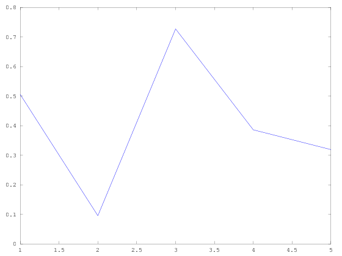

```matlab
plot(x)
```

```matlab
x = rand(100, 1);
y = rand(100, 1);
```

**2-dimensional**

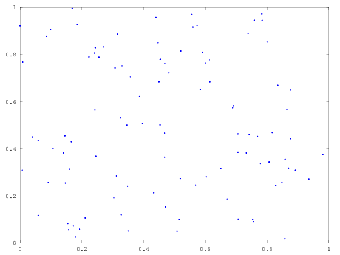

```matlab
plot(x, y, '.')
```

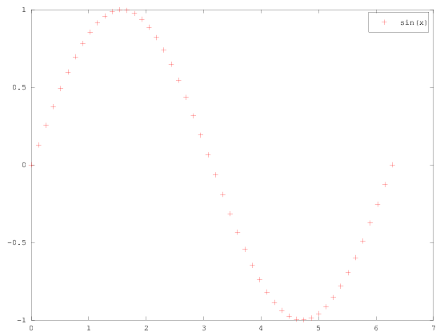

```matlab
x = linspace(0, 2*pi, 50);
y = sin(x);
plot(x, y, '+1;sin(x);');
```

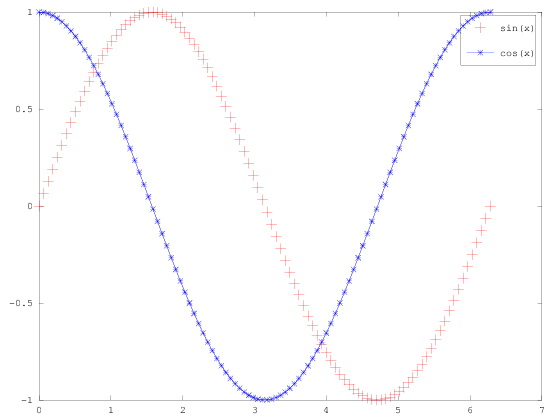

```matlab
x = linspace(0, 2*pi, 100);
y = sin(x);
y2 = cos(x);
plot(x, y, '+1;sin(x);', "markersize", 10, x, y2, ";cos(x);", "markersize", 5, "marker", '*');
```

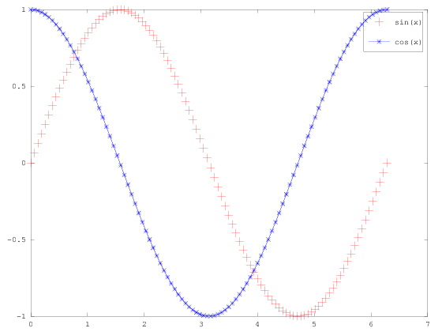

```matlab
plot(x, y, '+1;sin(x);', "markersize", 10);
hold on         # <--- will keep your current plot
plot(x, y2, ";cos(x);", "markersize", 5, "marker", '*')
```

Was noch fehlt sind Achsenbeschriftungen, und eventuell ein netteres Farbschema, durchgehende Linien statt Punkten etc:

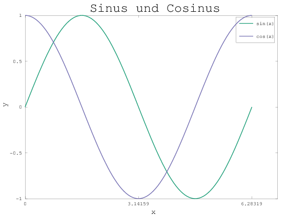

```matlab
plot(
    x, y,  "-;sin(x);",  "color", [27,158,119] ./255, "linewidth", 5,
    x, y2, "--;cos(x);", "color", [117,112,179] ./255, "linewidth", 5);
set(gca, 'xtick', [0, pi, 2*pi])
set(gca, 'interpreter', 'tex')
xlabel('{\fontsize{30} x}')
ylabel('{\fontsize{30} y}')
title('{\fontsize{50} Sinus und Cosinus}')
```

**Spalten einer Matrix als input für Plot:**

```matlab
X = randn(10, 4)
```

```
X =

   0.2076968   2.3774825  -1.6644998   0.3120677
   1.2433826  -0.3899325   1.4690659   0.6811347
  -1.2511684   1.4384095  -1.2521475  -0.4844797
  -1.4191697  -1.0268673  -1.7539299  -1.3431218
  -0.7769468  -0.5294416  -0.7095538  -1.5780682
  -0.5347750  -0.3869233  -0.5241037   1.0123902
   0.0083776  -0.1626238  -1.0788506   0.5800764
  -1.9944677   0.9136397   0.5874466   0.1336204
   0.8696625  -0.0866681  -1.5484536   0.3376812
   0.3168582  -0.2493764   0.7859746   1.1795414
```

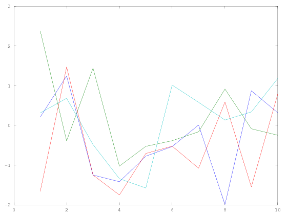

```matlab
plot(X)
```

## Und jetzt?

Dieses Tutorial ist nur ein kleiner Überblick - um besser mit Octave zurechtzukommen solltet Ihr euch eines der vielen anderen Tutorials im Internet oder die offizielle Dokumentation ansehen.